# Practical Homework 2: Support Vector Machines

Predicting Coronary Heart Disease from Health Behaviors and Demographics

Ruman Sidhu

Spring 2026 | DATA 5322

```r
library(tidyverse)
library(e1071)
library(caret)
library(pROC)
```

```r
# ── Global plot theme and palette ──────────────────────────────────────────────
COL_NO   <- "#0F3460"   # deep navy  → healthy
COL_YES  <- "#E94560"   # crimson    → heart disease
COL_BG   <- "#f8f9fc"
COL_GRID <- "#dde1ec"

theme_ph2 <- function(base_size = 13) {
  theme_minimal(base_size = base_size) %+replace%
    theme(
      plot.background   = element_rect(fill = COL_BG, color = NA),
      panel.background  = element_rect(fill = "white", color = NA),
      panel.grid.major  = element_line(color = COL_GRID, linewidth = 0.4),
      panel.grid.minor  = element_blank(),
      axis.title        = element_text(face = "bold", color = "#16213e"),
      axis.text         = element_text(color = "#3a3a5c"),
      plot.title        = element_text(face = "bold", color = "#16213e",
                                       size = base_size + 2, hjust = 0),
      plot.subtitle     = element_text(color = "#666699", size = base_size - 1, hjust = 0),
      plot.caption      = element_text(color = "#999999", size = 10, hjust = 1),
      legend.background = element_rect(fill = COL_BG, color = NA),
      legend.title      = element_text(face = "bold"),
      strip.background  = element_rect(fill = "#16213e"),
      strip.text        = element_text(color = "white", face = "bold")
    )
}

theme_set(theme_ph2())
```

## Research Question

Can we predict whether an adult has been diagnosed with coronary heart disease using their demographic characteristics and lifestyle habits? Using data from the 2022 National Health Interview Survey (NHIS), I apply linear, radial, and polynomial kernel SVMs to classify individuals as having or not having coronary heart disease.

## 1. Data Loading and Preparation

```r
# Load the NHIS 2022 dataset
nhis_raw <- read.csv("nhis_2022.csv")

cat("Raw dataset dimensions:", nrow(nhis_raw), "rows x", ncol(nhis_raw), "cols\n")
```

```
## Raw dataset dimensions: 35115 rows x 48 cols
```

### 1.1 Filter to Sample Adults

The dataset includes both adults and children. Since all disease and lifestyle variables are only asked of sample adults (ASTATFLG == 1), we restrict to this group.

```r
# Keep only sample adults (ASTATFLG = 1)
adults <- nhis_raw %>% filter(ASTATFLG == 1)

cat("Sample adults:", nrow(adults), "rows\n")
```

```
## Sample adults: 27651 rows
```

### 1.2 Missing Value Assessment

Before selecting predictors, I check the percentage of missing or invalid values per column in the adult sample. “Invalid” means any code flagged as Unknown, Refused, Not in Universe, or Not Calculable in the NHIS codebook.

```r
# Check missingness per variable of interest
# Using codebook-defined invalid codes for each variable
check_missing <- data.frame(
  Variable    = c("CHEARTDIEV", "AGE", "SEX", "BMICALC",
                  "HRSLEEP", "MOD10DMIN", "ALCDAYSYR",
                  "FRIESPNO", "POVERTY"),
  Invalid_Codes = c("0,7,9", "997-999", "7-9", "0,996",
                    "0,97-99", "996-999", "995-999",
                    "996-999", "98,99"),
  Pct_Invalid = c(
    round(mean(adults$CHEARTDIEV %in% c(0,7,9))     * 100, 1),
    round(mean(adults$AGE        %in% c(997,998,999))* 100, 1),
    round(mean(adults$SEX        %in% c(7,8,9))      * 100, 1),
    round(mean(adults$BMICALC    %in% c(0,996))       * 100, 1),
    round(mean(adults$HRSLEEP    %in% c(0,97,98,99)) * 100, 1),
    round(mean(adults$MOD10DMIN  %in% c(996,997,998,999)) * 100, 1),
    round(mean(adults$ALCDAYSYR  %in% c(995,997,998,999)) * 100, 1),
    round(mean(adults$FRIESPNO   %in% c(996,997,998,999)) * 100, 1),
    round(mean(adults$POVERTY    %in% c(98,99))       * 100, 1)
  )
)

knitr::kable(check_missing,
             col.names = c("Variable", "Invalid Codes (codebook)", "% Invalid"),
             caption   = "Per-column invalid/missing rate in adult sample",
             align     = "lcc")
```

Per-column invalid/missing rate in adult sample

| Variable | Invalid Codes (codebook) | % Invalid |
| --- | --- | --- |
| CHEARTDIEV | 0,7,9 | 0.3 |
| AGE | 997-999 | 0.2 |
| SEX | 7-9 | 0.0 |
| BMICALC | 0,996 | 8.6 |
| HRSLEEP | 0,97-99 | 3.5 |
| MOD10DMIN | 996-999 | 0.3 |
| ALCDAYSYR | 995-999 | 0.6 |
| FRIESPNO | 996-999 | 4.0 |
| POVERTY | 98,99 | 0.0 |

I selected 8 predictors covering demographics, physical health, activity, sleep, diet, and alcohol use. I recode all variables carefully using the NHIS codebook, converting “Unknown”, “Refused”, and “Not in Universe” codes to NA before any modeling.

```r
nhis_clean <- adults %>%

  # --- Target variable ---
  # CHEARTDIEV: 1 = No, 2 = Yes, 7/9 = Unknown → drop
  filter(CHEARTDIEV %in% c(1, 2)) %>%
  mutate(heart_disease = factor(
    ifelse(CHEARTDIEV == 2, "Yes", "No"),
    levels = c("No", "Yes")
  )) %>%

  # --- Predictor 1: Age ---
  # Values 997/998/999 = unknown; top code 85 means 85+
  mutate(AGE = ifelse(AGE %in% c(997, 998, 999), NA, AGE)) %>%

  # --- Predictor 2: Sex ---
  # 1 = Male, 2 = Female, 7/8/9 = Unknown → NA
  mutate(SEX = case_when(
    SEX == 1 ~ "Male",
    SEX == 2 ~ "Female",
    TRUE     ~ NA_character_
  ),
  SEX = factor(SEX)) %>%

  # --- Predictor 3: BMI ---
  # 0 = NIU, 996 = not calculable → NA
  mutate(BMICALC = ifelse(BMICALC %in% c(0, 996), NA, BMICALC)) %>%

  # --- Predictor 4: Sleep hours ---
  # 0 = NIU, 25 = less than 1 hour (keep as 0.5), 97/98/99 = unknown → NA
  mutate(HRSLEEP = case_when(
    HRSLEEP == 25 ~ 0.5,
    HRSLEEP %in% c(0, 97, 98, 99) ~ NA_real_,
    TRUE ~ as.numeric(HRSLEEP)
  )) %>%

  # --- Predictor 5: Moderate physical activity (minutes) ---
  # 0 = did not do moderate activity (valid: 0 min), 996/997/998/999 → NA
  mutate(MOD10DMIN = ifelse(MOD10DMIN %in% c(996, 997, 998, 999), NA, MOD10DMIN)) %>%

  # --- Predictor 6: Alcohol drinking days per year ---
  # 996 = NIU (never drinks) → treat as 0, 995 = inconsistent → NA, 997/998/999 → NA
  mutate(ALCDAYSYR = case_when(
    ALCDAYSYR == 996 ~ 0,
    ALCDAYSYR %in% c(995, 997, 998, 999) ~ NA_real_,
    TRUE ~ as.numeric(ALCDAYSYR)
  )) %>%

  # --- Predictor 7: Fried potato frequency ---
  # 0 = never, 995 = top code (keep), 996 = NIU → NA, 997/998/999 → NA
  mutate(FRIESPNO = ifelse(FRIESPNO %in% c(996, 997, 998, 999), NA, FRIESPNO)) %>%

  # --- Predictor 8: Income-to-poverty ratio (grouped) ---
  # Codes: 11-14 = below poverty, 21-25 = near poverty (1-2x), 30-38 = above poverty (2x+)
  # 98 = undefinable, 99 = unknown → NA
  mutate(POVERTY_GRP = case_when(
    POVERTY %in% 11:14 ~ "Below_poverty",
    POVERTY %in% 21:25 ~ "Near_poverty",
    POVERTY %in% 30:38 ~ "Above_poverty",
    TRUE               ~ NA_character_
  ),
  POVERTY_GRP = factor(POVERTY_GRP,
                       levels = c("Below_poverty", "Near_poverty", "Above_poverty"))) %>%

  # Keep only the columns we need
  select(heart_disease, AGE, SEX, BMICALC, HRSLEEP,
         MOD10DMIN, ALCDAYSYR, FRIESPNO, POVERTY_GRP) %>%

  # Drop rows with any NA
  drop_na()

cat("Clean dataset dimensions:", nrow(nhis_clean), "rows\n")
```

```
## Clean dataset dimensions: 23954 rows
```

```r
cat("\nClass distribution:\n")
```

```
##
## Class distribution:
```

```r
print(table(nhis_clean$heart_disease))
```

```
##
##    No   Yes
## 22452  1502
```

```r
cat("\nClass proportions:\n")
```

```
##
## Class proportions:
```

```r
print(round(prop.table(table(nhis_clean$heart_disease)), 3))
```

```
##
##    No   Yes
## 0.937 0.063
```

### 1.3 Exploratory Data Analysis

Before modeling, I take a quick look at how key variables differ between those with and without heart disease.

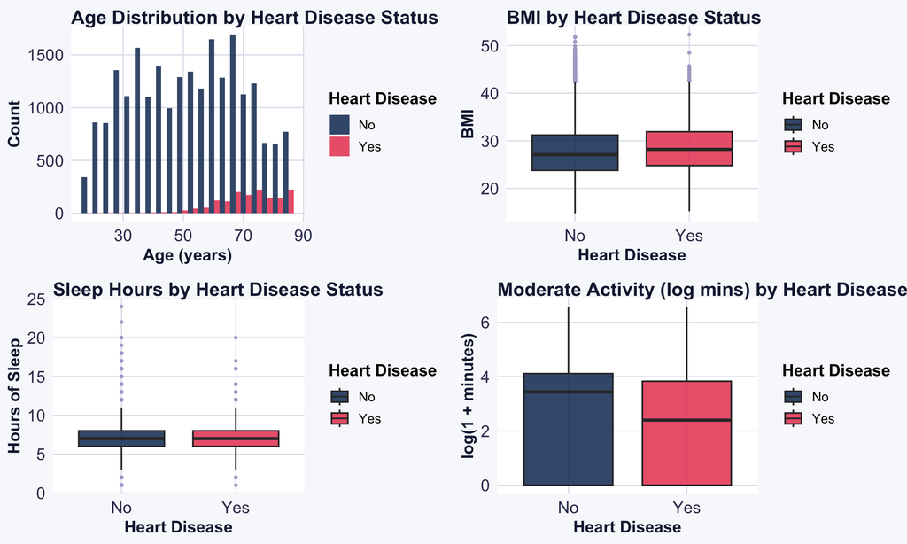

```r
# Age distribution by heart disease status
p1 <- ggplot(nhis_clean, aes(x = AGE, fill = heart_disease)) +
  geom_histogram(position = "dodge", bins = 20, alpha = 0.85) +
  scale_fill_manual(values = c("No" = COL_NO, "Yes" = COL_YES)) +
  labs(title = "Age Distribution by Heart Disease Status",
       x = "Age (years)", y = "Count", fill = "Heart Disease")

# BMI distribution
p2 <- ggplot(nhis_clean, aes(x = heart_disease, y = BMICALC, fill = heart_disease)) +
  geom_boxplot(alpha = 0.85, outlier.color = "#aaaacc", outlier.size = 0.8) +
  scale_fill_manual(values = c("No" = COL_NO, "Yes" = COL_YES)) +
  labs(title = "BMI by Heart Disease Status",
       x = "Heart Disease", y = "BMI", fill = "Heart Disease")

# Sleep hours
p3 <- ggplot(nhis_clean, aes(x = heart_disease, y = HRSLEEP, fill = heart_disease)) +
  geom_boxplot(alpha = 0.85, outlier.color = "#aaaacc", outlier.size = 0.8) +
  scale_fill_manual(values = c("No" = COL_NO, "Yes" = COL_YES)) +
  labs(title = "Sleep Hours by Heart Disease Status",
       x = "Heart Disease", y = "Hours of Sleep", fill = "Heart Disease")

# Physical activity
p4 <- ggplot(nhis_clean, aes(x = heart_disease, y = log1p(MOD10DMIN), fill = heart_disease)) +
  geom_boxplot(alpha = 0.85, outlier.color = "#aaaacc", outlier.size = 0.8) +
  scale_fill_manual(values = c("No" = COL_NO, "Yes" = COL_YES)) +
  labs(title = "Moderate Activity (log mins) by Heart Disease",
       x = "Heart Disease", y = "log(1 + minutes)", fill = "Heart Disease")

gridExtra::grid.arrange(p1, p2, p3, p4, ncol = 2)
```

## 2. Train/Test Split and Subsampling

```r
set.seed(42)

# Stratified sample: 3000 for train+tune, rest for test
# First create a 70/30 split from the full cleaned data
train_index <- createDataPartition(nhis_clean$heart_disease, p = 0.7, list = FALSE)
train_full  <- nhis_clean[train_index, ]
test_set    <- nhis_clean[-train_index, ]

# Further sample training to 3000 rows for tuning speed
# (still stratified so class balance is preserved)
set.seed(42)
train_idx_small <- createDataPartition(train_full$heart_disease, p = 3000/nrow(train_full), list = FALSE)
train_set <- train_full[train_idx_small, ]

cat("Training set size:", nrow(train_set), "\n")
```

```
## Training set size: 3001
```

```r
cat("Test set size:    ", nrow(test_set), "\n")
```

```
## Test set size:     7185
```

```r
cat("\nTraining class distribution:\n")
```

```
##
## Training class distribution:
```

```r
print(table(train_set$heart_disease))
```

```
##
##   No  Yes
## 2812  189
```

```r
cat("\nTest class distribution:\n")
```

```
##
## Test class distribution:
```

```r
print(table(test_set$heart_disease))
```

```
##
##   No  Yes
## 6735  450
```

### Class Imbalance: Why It Matters

Only about 6% of respondents have been diagnosed with coronary heart disease. If we naively train a model, it will simply predict “No” for everyone and still achieve ~94% accuracy-which is meaningless. To address this, I use **class weights** in all SVM models, penalizing misclassification of the minority class (“Yes”) more heavily than the majority.

## 3. SVM Model Training

SVMs find a maximum-margin hyperplane that separates classes. When classes are not linearly separable, kernels implicitly project data into higher-dimensional spaces where separation becomes possible. The key hyperparameters are:

- **C (cost)**: controls the trade-off between margin width and training errors. Larger C = tighter fit, more risk of overfitting.
- **gamma** (radial/polynomial): controls how far the influence of each training point reaches. Smaller gamma = wider influence.
- **degree** (polynomial): controls the polynomial complexity.

### 3.1 Linear SVM

A linear kernel is the simplest case-it draws a straight hyperplane. Interpretable and fast to tune.

```r
# Class weights to handle imbalance
# Penalize missing a heart disease case more than missing a healthy case
n_no  <- sum(train_set$heart_disease == "No")
n_yes <- sum(train_set$heart_disease == "Yes")
wt_no  <- 1
wt_yes <- n_no / n_yes  # inverse frequency weighting
class_wts <- c("No" = wt_no, "Yes" = wt_yes)

cat("Class weights-No:", round(wt_no, 2), "| Yes:", round(wt_yes, 2), "\n")
```

```
## Class weights-No: 1 | Yes: 14.88
```

```r
# Tune C for linear kernel using 5-fold cross-validation
set.seed(42)
tune_linear <- tune(
  svm,
  heart_disease ~ .,
  data       = train_set,
  kernel     = "linear",
  ranges     = list(cost = c(0.01, 0.1, 1, 10)),
  class.weights = class_wts,
  tunecontrol = tune.control(cross = 5)
)

cat("\nLinear SVM tuning results:\n")
```

```
##
## Linear SVM tuning results:
```

```r
print(tune_linear$performances)
```

```
##    cost     error dispersion
## 1  0.01 0.3052263 0.01595541
## 2  0.10 0.2872335 0.01923393
## 3  1.00 0.2842329 0.01963218
## 4 10.00 0.2848991 0.02009372
```

```r
cat("\nBest cost:", tune_linear$best.parameters$cost, "\n")
```

```
##
## Best cost: 1
```

```r
# Fit final linear SVM with best parameters
set.seed(42)
svm_linear <- svm(
  heart_disease ~ .,
  data          = train_set,
  kernel        = "linear",
  cost          = tune_linear$best.parameters$cost,
  class.weights = class_wts,
  probability   = TRUE
)

cat("Linear SVM fitted.\n")
```

```
## Linear SVM fitted.
```

### 3.2 Radial (RBF) Kernel SVM

The radial basis function kernel handles non-linear boundaries by measuring similarity via Euclidean distance in feature space. Requires tuning both C and gamma.

```r
set.seed(42)
tune_radial <- tune(
  svm,
  heart_disease ~ .,
  data       = train_set,
  kernel     = "radial",
  ranges     = list(
    cost  = c(0.1, 1, 10),
    gamma = c(0.001, 0.01, 0.1)
  ),
  class.weights = class_wts,
  tunecontrol   = tune.control(cross = 5)
)

cat("Radial SVM tuning results:\n")
```

```
## Radial SVM tuning results:
```

```r
print(tune_radial$performances)
```

```
##   cost gamma     error dispersion
## 1  0.1 0.001 0.4325164 0.04251700
## 2  1.0 0.001 0.3352174 0.01921139
## 3 10.0 0.001 0.2985618 0.02292372
## 4  0.1 0.010 0.3378835 0.01645419
## 5  1.0 0.010 0.3008974 0.01761011
## 6 10.0 0.010 0.2832324 0.01919935
## 7  0.1 0.100 0.2958952 0.02236237
## 8  1.0 0.100 0.2669057 0.02200568
## 9 10.0 0.100 0.2325824 0.02364346
```

```r
cat("\nBest cost:", tune_radial$best.parameters$cost,
    "| Best gamma:", tune_radial$best.parameters$gamma, "\n")
```

```
##
## Best cost: 10 | Best gamma: 0.1
```

```r
set.seed(42)
svm_radial <- svm(
  heart_disease ~ .,
  data          = train_set,
  kernel        = "radial",
  cost          = tune_radial$best.parameters$cost,
  gamma         = tune_radial$best.parameters$gamma,
  class.weights = class_wts,
  probability   = TRUE
)

cat("Radial SVM fitted.\n")
```

```
## Radial SVM fitted.
```

### 3.3 Polynomial Kernel SVM

The polynomial kernel captures interactions between features at a given degree. Degree 2 captures pairwise interactions, degree 3 adds cubic relationships.

```r
set.seed(42)
tune_poly <- tune(
  svm,
  heart_disease ~ .,
  data       = train_set,
  kernel     = "polynomial",
  ranges     = list(
    cost   = c(0.1, 1, 10),
    degree = c(2, 3)
  ),
  class.weights = class_wts,
  tunecontrol   = tune.control(cross = 5)
)

cat("Polynomial SVM tuning results:\n")
```

```
## Polynomial SVM tuning results:
```

```r
print(tune_poly$performances)
```

```
##   cost degree     error dispersion
## 1  0.1      2 0.2705724 0.01872618
## 2  1.0      2 0.2698996 0.02395929
## 3 10.0      2 0.2795580 0.03955035
## 4  0.1      3 0.2132557 0.01573330
## 5  1.0      3 0.2389124 0.02257055
## 6 10.0      3 0.2479124 0.02306419
```

```r
cat("\nBest cost:", tune_poly$best.parameters$cost,
    "| Best degree:", tune_poly$best.parameters$degree, "\n")
```

```
##
## Best cost: 0.1 | Best degree: 3
```

```r
set.seed(42)
svm_poly <- svm(
  heart_disease ~ .,
  data          = train_set,
  kernel        = "polynomial",
  cost          = tune_poly$best.parameters$cost,
  degree        = tune_poly$best.parameters$degree,
  class.weights = class_wts,
  probability   = TRUE
)

cat("Polynomial SVM fitted.\n")
```

```
## Polynomial SVM fitted.
```

## 4. Model Evaluation

I evaluate each model on the held-out test set. Given the class imbalance, I report accuracy, sensitivity (recall for “Yes”-catching actual heart disease cases), specificity, and AUC-ROC. Sensitivity is the most clinically meaningful metric here: missing a true heart disease case is more costly than a false alarm.

```r
# Helper: evaluate a fitted SVM on the test set
evaluate_svm <- function(model, test_data, model_name) {

  preds <- predict(model, test_data)
  probs <- attr(predict(model, test_data, probability = TRUE), "probabilities")[, "Yes"]

  cm <- confusionMatrix(preds, test_data$heart_disease, positive = "Yes")
  roc_obj <- roc(test_data$heart_disease, probs, levels = c("No", "Yes"), quiet = TRUE)

  cat("==========", model_name, "==========\n")
  cat("Accuracy:   ", round(cm$overall["Accuracy"], 4), "\n")
  cat("Sensitivity:", round(cm$byClass["Sensitivity"], 4), "(recall for Yes)\n")
  cat("Specificity:", round(cm$byClass["Specificity"], 4), "\n")
  cat("AUC-ROC:    ", round(auc(roc_obj), 4), "\n\n")

  print(cm$table)
  cat("\n")

  return(list(cm = cm, roc = roc_obj, preds = preds, probs = probs))
}
```

```r
results_linear <- evaluate_svm(svm_linear, test_set, "Linear SVM")
```

```
## ========== Linear SVM ==========
## Accuracy:    0.6882
## Sensitivity: 0.84 (recall for Yes)
## Specificity: 0.6781
## AUC-ROC:     0.8252
##
##           Reference
## Prediction   No  Yes
##        No  4567   72
##        Yes 2168  378
```

```r
results_radial <- evaluate_svm(svm_radial, test_set, "Radial SVM")
```

```
## ========== Radial SVM ==========
## Accuracy:    0.7539
## Sensitivity: 0.6956 (recall for Yes)
## Specificity: 0.7578
## AUC-ROC:     0.7823
##
##           Reference
## Prediction   No  Yes
##        No  5104  137
##        Yes 1631  313
```

```r
results_poly   <- evaluate_svm(svm_poly,   test_set, "Polynomial SVM")
```

```
## ========== Polynomial SVM ==========
## Accuracy:    0.7594
## Sensitivity: 0.7156 (recall for Yes)
## Specificity: 0.7623
## AUC-ROC:     0.8107
##
##           Reference
## Prediction   No  Yes
##        No  5134  128
##        Yes 1601  322
```

### 4.1 ROC Curve Comparison

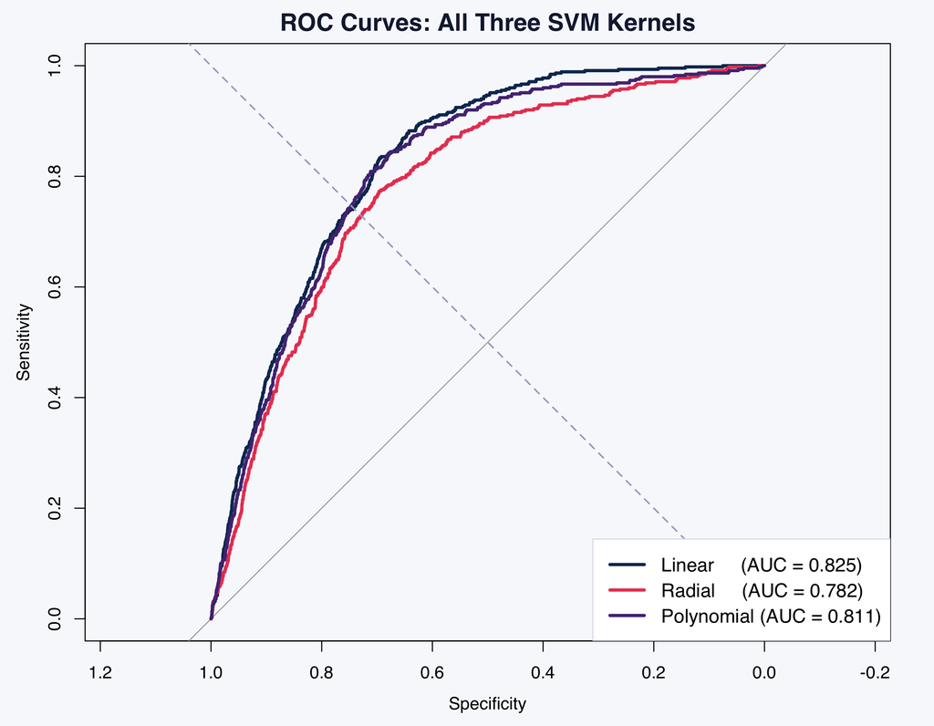

```r
# Plot all three ROC curves together
par(bg = COL_BG, col.main = "#16213e", family = "sans")
plot(results_linear$roc, col = "#0F3460", lwd = 3,
     main = "ROC Curves: All Three SVM Kernels",
     cex.main = 1.4, col.main = "#16213e")
plot(results_radial$roc, col = "#E94560", lwd = 3, add = TRUE)
plot(results_poly$roc,   col = "#533483", lwd = 3, add = TRUE)
abline(a = 0, b = 1, lty = 2, col = "#aaaacc", lwd = 1.5)

legend("bottomright",
       legend = c(
         paste0("Linear     (AUC = ", round(auc(results_linear$roc), 3), ")"),
         paste0("Radial     (AUC = ", round(auc(results_radial$roc), 3), ")"),
         paste0("Polynomial (AUC = ", round(auc(results_poly$roc),   3), ")")
       ),
       col = c("#0F3460", "#E94560", "#533483"),
       lwd = 3, cex = 1.1, bg = "white", box.col = "#dde1ec")
```

### 4.2 Decision Boundary Visualization

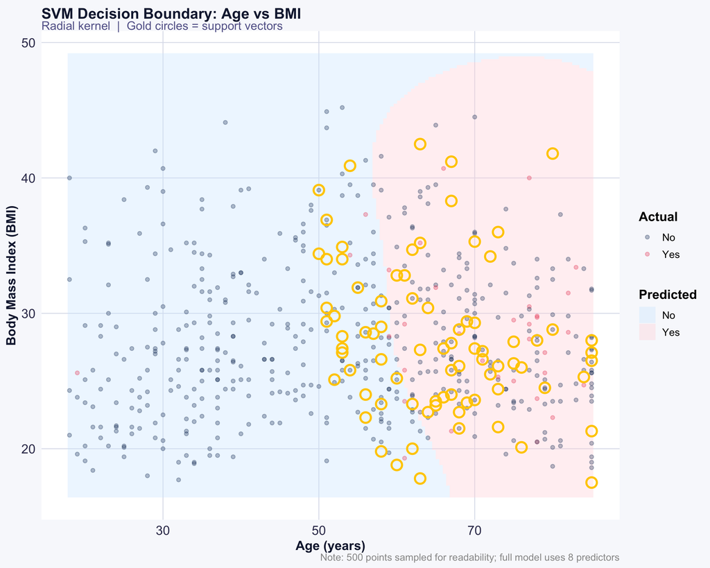

```r
# Fit a 2D radial SVM on just AGE and BMICALC for visualization
set.seed(42)
# Fit 2D SVM for visualization
svm_2d <- svm(
  heart_disease ~ AGE + BMICALC,
  data          = train_set,
  kernel        = "radial",
  cost          = tune_radial$best.parameters$cost,
  gamma         = tune_radial$best.parameters$gamma,
  class.weights = class_wts
)

# Create prediction grid
age_range <- seq(min(train_set$AGE), max(train_set$AGE), length.out = 150)
bmi_range <- seq(min(train_set$BMICALC), max(train_set$BMICALC), length.out = 150)
grid_2d <- expand.grid(AGE = age_range, BMICALC = bmi_range)
grid_2d$pred <- predict(svm_2d, grid_2d)
plot_sample <- train_set[sample(nrow(train_set), 500), ]
sv_data_plot <- train_set[svm_2d$index, ][sample(length(svm_2d$index), min(80, length(svm_2d$index))), ]

ggplot() +
  geom_tile(data = grid_2d,
            aes(x = AGE, y = BMICALC, fill = pred),
            alpha = 0.35) +
  geom_point(data = plot_sample,
             aes(x = AGE, y = BMICALC, color = heart_disease),
             size = 1.5, alpha = 0.3) +
  geom_point(data = sv_data_plot,
             aes(x = AGE, y = BMICALC),
             shape = 1, size = 4, color = "#ffcc00", stroke = 1.5) +
  scale_fill_manual(values = c("No" = "#d0e8ff", "Yes" = "#ffd6dc"), name = "Predicted") +
  scale_color_manual(values = c("No" = "#0F3460", "Yes" = "#E94560"), name = "Actual") +
  labs(
    title    = "SVM Decision Boundary: Age vs BMI",
    subtitle = "Radial kernel  |  Gold circles = support vectors",
    x = "Age (years)", y = "Body Mass Index (BMI)",
    caption = "Note: 500 points sampled for readability; full model uses 8 predictors"
  )
```

## 5. Model Comparison Summary

```r
# Build a clean comparison table
comparison <- data.frame(
  Kernel       = c("Linear", "Radial", "Polynomial"),
  Best_C       = c(tune_linear$best.parameters$cost,
                   tune_radial$best.parameters$cost,
                   tune_poly$best.parameters$cost),
  Other_Param  = c("—",
                   paste0("gamma = ", tune_radial$best.parameters$gamma),
                   paste0("degree = ", tune_poly$best.parameters$degree)),
  Accuracy     = round(c(
    results_linear$cm$overall["Accuracy"],
    results_radial$cm$overall["Accuracy"],
    results_poly$cm$overall["Accuracy"]
  ), 4),
  Sensitivity  = round(c(
    results_linear$cm$byClass["Sensitivity"],
    results_radial$cm$byClass["Sensitivity"],
    results_poly$cm$byClass["Sensitivity"]
  ), 4),
  Specificity  = round(c(
    results_linear$cm$byClass["Specificity"],
    results_radial$cm$byClass["Specificity"],
    results_poly$cm$byClass["Specificity"]
  ), 4),
  AUC          = round(c(
    as.numeric(auc(results_linear$roc)),
    as.numeric(auc(results_radial$roc)),
    as.numeric(auc(results_poly$roc))
  ), 4)
)

knitr::kable(comparison,
             caption = "Model Performance Comparison on Held-Out Test Set",
             align   = "lcccccc")
```

Model Performance Comparison on Held-Out Test Set

| Kernel | Best_C | Other_Param | Accuracy | Sensitivity | Specificity | AUC |
| --- | --- | --- | --- | --- | --- | --- |
| Linear | 1.0 | — | 0.6882 | 0.8400 | 0.6781 | 0.8252 |
| Radial | 10.0 | gamma = 0.1 | 0.7539 | 0.6956 | 0.7578 | 0.7823 |
| Polynomial | 0.1 | degree = 3 | 0.7594 | 0.7156 | 0.7623 | 0.8107 |

## 6. Discussion

The dataset presents a classic **class imbalance** problem: only ~6% of adults reported a heart disease diagnosis. Without class weights, all three models would simply predict “No” for nearly everyone and still achieve ~94% accuracy-a hollow metric. By weighting the minority class inversely proportional to its frequency, we push the models to actually learn the patterns associated with heart disease, even at the cost of some overall accuracy.

Model limitations worth noting: the NHIS is a cross-sectional self-report survey. The target variable (“ever told by a doctor”) is subject to detection bias-people without healthcare access may have undiagnosed conditions. The dataset is also not a nationally representative sample without applying the SAMPWEIGHT variable (which we did not use here), so extrapolating these findings to the broader US population requires caution.

## References

[1] Lynn A. Blewett, Julia A. Rivera Drew, Miriam L. King, Kari C.W. Williams, Daniel Backman, Annie Chen, and Stephanie Richards. *IPUMS Health Surveys: National Health Interview Survey, Version 7.4* [dataset]. Minneapolis, MN: IPUMS, 2024. https://doi.org/10.18128/D070.V7.4. http://www.nhis.ipums.org.